# EP07

2025-11-27

### Enunciado

En el trabajo de título de una estudiante del DIINF se reportan tiempos de ejecución (en milisegundos) y la cercanía con la solución óptima (en por ciento) de la mejor solución encontrada con tres versiones de un algoritmo genético para resolver instancias del problema del vendedor viajero disponibles en repositorios públicos. Ahora debe enfrentar el análisis de estos datos, por que está solicitando ayuda de las y los estudiantes de Estadística Inferencial.

### Pregunta 1

1. Observando los datos, la memorista sospecha que hay diferencias significativas en el tiempo de ejecución entre las versiones B y C del algoritmo cuando las instancias tienen 60 o más nodos. ¿Los datos respaldan la intuición de la memorista?

Para responder, filtren los datos para tener las instancias con 60 o más nodos y seleccionen las columnas de los tiempos de ejecución de las versiones B y C en formato ancho. Usando como semilla el valor 71, obtenga muestras aleatorias independientes de 22 tiempos registrados por la versión B y 19 tiempos registrados por la versión C del algoritmo. Realicen un análisis estadístico pertinente (enunciar hipótesis, revisar condiciones, seleccionar pruebas ómnibus y post-hoc según corresponda) para responder la pregunta planteada, utilizando pruebas no paramétricas de ser necesario.

### Hipótesis:

H0: Las distribuciones de tiempos entre versiones B y C son iguales.

H1: Las distribuciones difieren (B ≠ C).

Aquí: la prueba ómnibus sería Wilcoxon, porque no se requieren pruebas post-hoc al comparar solo dos grupos.

### Extracción de datos:

```r
library(dplyr)
library(ggplot2)

set.seed(71)

datos<-read.csv("EP07 Datos.csv")

datos_filtrados1<- datos %>% filter(n.nodos>= 60)

muestra_B<-sample(datos_filtrados1$tiempo.B, size= 22, replace = FALSE)
muestra_C<-sample(datos_filtrados1$tiempo.C, size = 19, replace= FALSE)
```

### Verificación de condiciones:

1. Escala de medición: La variable dependiente es “tiempo de ejecución” (milisegundos). Al ser una variable cuantitativa continua (escala de razón), permite establecer un orden entre las observaciones, cumpliendo y excediendo el requisito de ser “al menos de escala ordinal.
2. Normalidad de las muestras:

```r
shapiro.test(muestra_B)
```

```
##
##  Shapiro-Wilk normality test
##
## data:  muestra_B
## W = 0.9592, p-value = 0.4733
```

```r
shapiro.test(muestra_C)
```

```
##
##  Shapiro-Wilk normality test
##
## data:  muestra_C
## W = 0.89131, p-value = 0.03397
```

Como el p-valor de la muestra B es 0.4733 y el de muestra C es 0.03397 podemos concluir que la muestra B proviene de una población con distribución normal, pero la muestra C no.

Apoyo gráfico:

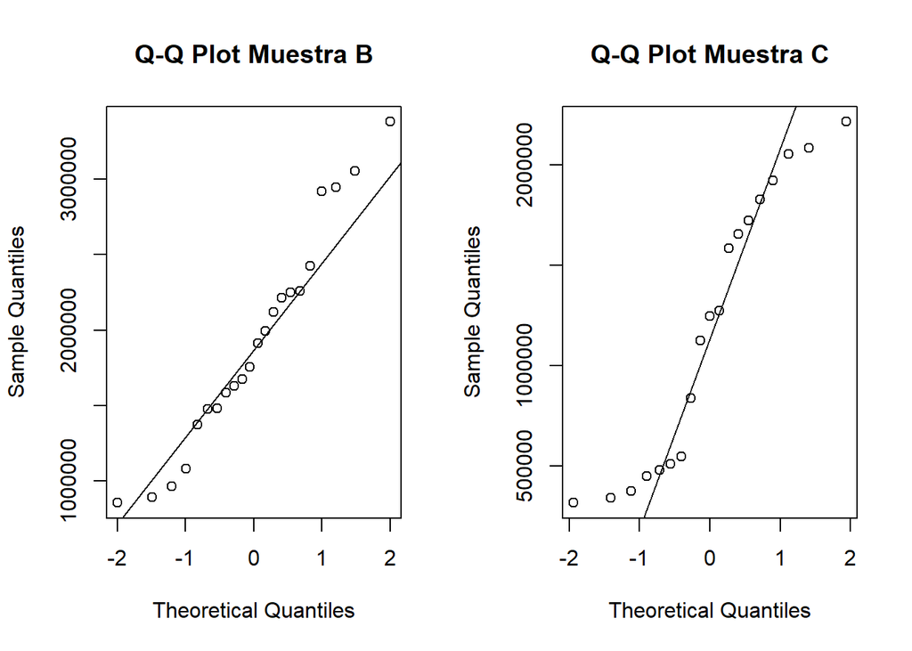

```r
par(mfrow=c(1,2))
qqnorm(muestra_B, main="Q-Q Plot Muestra B")
qqline(muestra_B)
qqnorm(muestra_C, main="Q-Q Plot Muestra C")
qqline(muestra_C)
```

```r
par(mfrow=c(1,1))
```

3. Independencia de las observaciones: Según el enunciado, las muestras son independientes entre sí.

Puesto que no se cumple con normalidad optamos por una prueba no paramétrica(Wilcoxon Mann-Whitney).

Para poder hacer la prueba no parametrica se deben cumplir las siguientes condiciones:

- Las muestras deben ser independientes.
- Las variables deben ser al menos de escala ordinal.

Ambas condiciones se cumplen.

### Prueba estadística:

```r
wilcox.test(muestra_B, muestra_C, paired=FALSE, alternative = "two.sided", conf.level = 0.95)
```

```
##
##  Wilcoxon rank sum exact test
##
## data:  muestra_B and muestra_C
## W = 317, p-value = 0.004126
## alternative hypothesis: true location shift is not equal to 0
```

El resultado de la prueba arrojó un valor p = 0.004126, menor que 0.05, lo que lleva a rechazar la hipótesis nula. Esto indica que existe evidencia estadísticamente significativa para concluir que los tiempos de ejecución entre las versiones B y C del algoritmo no son iguales cuando se consideran instancias de 60 o más nodos.

### Pregunta 2

2. La memorista también sospecha que, al comparar las mismas instancias de iguales características, las mejores soluciones encontradas por las versiones B y C tienen rendimientos distintos. ¿Estará en lo cierto? Para responder, filtren los datos para tener las instancias con 60 o más nodos y seleccionen las columnas con el mejor rendimiento de las versiones B y C en formato ancho. Usando como semilla el valor 33, obtengan una muestra aleatoria de 20 instancias. Realicen un análisis estadístico pertinente (enunciar hipótesis, revisar condiciones, seleccionar pruebas ómnibus y post-hoc según corresponda) para responder la pregunta planteada, utilizando pruebas no paramétricas de ser necesario.

### Hipótesis:

H0: La distribución de las diferencias (mejor.B – mejor.C) es simétrica alrededor de cero.

H1: Las diferencias no son cero (rendimientos distintos).

### Extracción de datos:

```r
set.seed(33)

indices <- sample(1:nrow(datos_filtrados1), size = 20, replace = FALSE)
datos_filtrados2 <- datos_filtrados1[indices, ]

datos_filtrados2<-datos_filtrados2 %>% select(instancia, mejor.B, mejor.C)
```

### Verificación de condiciones:

1. Escala de medición: La variable dependiente “rendimiento” es cuantitativa continua. Esto cumple con el requisito para pruebas paramétricas (T-Student) y excede el requisito de escala ordinal para pruebas no paramétricas.
2. Normalidad de las diferencias:

```r
diferencia <- datos_filtrados2$mejor.B - datos_filtrados2$mejor.C

shapiro_diff <- shapiro.test(diferencia)
print(shapiro_diff)
```

```
##
##  Shapiro-Wilk normality test
##
## data:  diferencia
## W = 0.97256, p-value = 0.8077
```

al obtener un p-valor de 0.8077, se concluye que las diferencias siguen una distribución normal Por lo que no es necesario utilizar una prueba no paramétrica.

### Prueba estadística:

```r
t.test(datos_filtrados2$mejor.B,
       datos_filtrados2$mejor.C,
       paired = TRUE,
       conf.level = 0.95)
```

```
##
##  Paired t-test
##
## data:  datos_filtrados2$mejor.B and datos_filtrados2$mejor.C
## t = -2.4409, df = 19, p-value = 0.02461
## alternative hypothesis: true mean difference is not equal to 0
## 95 percent confidence interval:
##  -3.3778464 -0.2591536
## sample estimates:
## mean difference
##         -1.8185
```

Como p = 0.02461 < 0.05, se rechaza la hipótesis nula. Por lo tanto, existe evidencia estadísticamente significativa con un 95% de confianza para afirmar que los rendimientos medios de las versiones B y C del algoritmo son distintos cuando se aplican a las mismas instancias.

### Análisis de Robustez (Validación):

Si bien la prueba T es la indicada dada la normalidad, realizaremos adicionalmente la prueba de rangos con signo de Wilcoxon para verificar si la conclusión se mantiene con un método no paramétrico (más robusto ante outliers).

```r
w_test <- wilcox.test(datos_filtrados2$mejor.B,
                      datos_filtrados2$mejor.C,
                      paired = TRUE,
                      alternative = "two.sided",
                      conf.level = 0.95)
print(w_test)
```

```
##
##  Wilcoxon signed rank test with continuity correction
##
## data:  datos_filtrados2$mejor.B and datos_filtrados2$mejor.C
## V = 46.5, p-value = 0.03035
## alternative hypothesis: true location shift is not equal to 0
```

Como p = 0.03035 < 0.05, se rechaza la hipótesis nula. Por lo tanto, existe evidencia estadísticamente significativa con un 95% de confianza para afirmar que los rendimientos de las versiones B y C del algoritmo son distintos cuando se aplican a las mismas instancias.

### Conclusión final de todo:

El análisis de normalidad sobre las diferencias arrojó un p-valor de 0.8077, permitiendo el uso de la prueba T de Student pareada. Esta prueba indicó una diferencia significativa (p = 0.0246). Adicionalmente, se realizó la prueba de rangos con signo de Wilcoxon como validación de robustez, obteniendo también un resultado significativo (p = 0.0303). Ambos métodos confirman que existe evidencia suficiente para rechazar la hipótesis nula.

### Pregunta 3

3. La memorista sospecha que hay diferencias significativas en el tiempo de ejecución entre las versiones del algoritmo cuando las instancias de prueba tienen 60 o más nodos. ¿Los datos respaldan la intuición de la memorista? Para responder, filtren los datos para tener las instancias con 60 o más nodos y seleccionen las columnas con los tiempos de ejecución registrados (en formato ancho). Usando como semilla el valor 31, obtengan muestras aleatorias independientes de 15, 14 y 13 tiempos registrados por las versiones A, B y C, respectivamente. Realicen un análisis estadístico pertinente (enunciar hipótesis, revisar condiciones, seleccionar pruebas ómnibus y post-hoc según corresponda) para responder la pregunta planteada, utilizando pruebas no paramétricas de ser necesario.

### Hipótesis:

H0: Las distribuciones de tiempos de A, B y C son iguales.

H1: Al menos una de las versiones tiene tiempos distintos.

### Extracción de datos:

```r
set.seed(31)

muestra_a = sample(datos_filtrados1$tiempo.A, size=15, replace=FALSE)
muestra_b = sample(datos_filtrados1$tiempo.B, size=14, replace=FALSE)
muestra_c = sample(datos_filtrados1$tiempo.C, size=13, replace=FALSE)
```

#### Verificación de condiciones:

1. Escala de medición: Variable cuantitativa (tiempo en ms), cumple con ser al menos ordinal.
2. Normalidad de las muestras:

```r
shapiro.test(muestra_a)
```

```
##
##  Shapiro-Wilk normality test
##
## data:  muestra_a
## W = 0.86004, p-value = 0.02417
```

```r
shapiro.test(muestra_b)
```

```
##
##  Shapiro-Wilk normality test
##
## data:  muestra_b
## W = 0.96567, p-value = 0.8141
```

```r
shapiro.test(muestra_c)
```

```
##
##  Shapiro-Wilk normality test
##
## data:  muestra_c
## W = 0.94103, p-value = 0.4704
```

Como el p-valor de la muestra_a es 0.02417, el de muestra_b es 0.8141 y el de muestra_c es 0.4704, podemos concluir que debido a que la muestra a no sigue una distribución normal por lo que podemos usar la prueba no parametrica de Kruskal-Wallis.

### Prueba estadística:

```r
tiempo<-c(muestra_a,muestra_b,muestra_c)

criterio<-c(rep("A",15),rep("B",14),rep("C",13))
criterio<-factor(criterio)
datos_3<-data.frame(tiempo,criterio)

kruskal.test(tiempo ~ criterio, data = datos_3)
```

```
##
##  Kruskal-Wallis rank sum test
##
## data:  tiempo by criterio
## Kruskal-Wallis chi-squared = 11.449, df = 2, p-value = 0.003265
```

```r
pairwise.wilcox.test(
  datos_3$tiempo,
  datos_3$criterio,
  p.adjust.method = "holm"
)
```

```
##
##  Pairwise comparisons using Wilcoxon rank sum exact test
##
## data:  datos_3$tiempo and datos_3$criterio
##
##   A      B
## B 0.0275 -
## C 0.7510 0.0013
##
## P value adjustment method: holm
```

como en el test de kruskal.test() dio un resultado de p <0.05 existe evidencia suficiente para concluir que no todas las versiones del algoritmo tienen el mismo tiempo de ejecución.

el procedimiento post-hoc indico que:

- B es significativamente diferente de A
- C no es diferente de A
- B es significativamente diferente de C

### Pregunta 4

4. La memorista también sospecha que, al comparar las mismas instancias con iguales características, las mejores soluciones encontradas por las diferentes versiones del algoritmo tienen rendimientos distintos. ¿Estará en lo cierto? Para responder, filtren los datos para tener las instancias con 60 o más nodos y seleccionen las columnas con los mejores rendimientos registrados. Usando como semilla el valor 73, obtengan una muestra aleatoria de 22 instancias. Realicen un análisis estadístico pertinente (enunciar hipótesis, revisar condiciones, seleccionar pruebas ómnibus y post-hoc según corresponda) para responder la pregunta planteada, utilizando pruebas no paramétricas de ser necesario.

H0: Las distribuciones de los rendimientos de las versiones del algoritmo son iguales.

H1: Al menos una versión del algoritmo difiere en su rendimiento con respecto a las otras.

### Extracción de datos:

```r
library(tidyr)

set.seed(73)

indices <- sample(1:nrow(datos_filtrados1), size = 22, replace = FALSE)
datos_filtrados4 <- datos_filtrados1[indices, ]

datos_filtrados4 <- datos_filtrados4 %>% select(instancia, mejor.A, mejor.B, mejor.C)

datos_largos <- datos_filtrados4 %>%
  pivot_longer(
    cols = c(mejor.A, mejor.B, mejor.C),
    names_to = "version",
    values_to = "rendimiento"
  )

datos_largos$version <- as.factor(datos_largos$version)
datos_largos$instancia <- as.factor(datos_largos$instancia)
```

### Verificación de condiciones:

Para este caso se utilizará la prueba de Friedman, por lo que se deben cumplir las siguientes condiciones:

- Las muestras son dependientes (las versiones se aplican a las mismas instancias).
- La variable dependiente es al menos de escala ordinal.

Ambas condiciones se cumplen.

### Prueba estadística:

```r
prueba<-friedman.test(rendimiento~version | instancia, data = datos_largos)

print(prueba)
```

```
##
##  Friedman rank sum test
##
## data:  rendimiento and version and instancia
## Friedman chi-squared = 6.6364, df = 2, p-value = 0.03622
```

como el p-value de la prueba friedman es 0.03622 < 0.05, se rechaza la hipótesis nula. Por lo tanto, existe evidencia estadísticamente significativa para afirmar que al menos una versión del algoritmo difiere en su rendimiento con respecto a las otras cuando se aplican a las mismas instancias.

### Análisis post-hoc:

```r
pairwise.wilcox.test(
    datos_largos$rendimiento,
    datos_largos$version,
    p.adjust.method = "holm",
    paired = TRUE
)
```

```
##
##  Pairwise comparisons using Wilcoxon signed rank exact test
##
## data:  datos_largos$rendimiento and datos_largos$version
##
##         mejor.A mejor.B
## mejor.B 0.014   -
## mejor.C 0.290   0.085
##
## P value adjustment method: holm
```

### Resultados del análisis

Prueba Post-hoc:

-A vs B (p = 0.014): Es menor a 0.05. Existe una diferencia significativa entre la versión A y la versión B.

-A vs C (p = 0.290): No hay diferencia significativa.

-B vs C (p = 0.085): No hay diferencia significativa.